# Cross-Validation

Lab 4C

Directions: Follow along with the slides, completing the questions in **blue** on your computer, and answering the questions in **red** in your journal.  
Space, Click, Right Arrow or swipe left to move to the next slide.

# What is cross-validation?

- In the previous two labs, we learned how to:
  - Create a linear model predicting `height` from the `arm_span` data (4A).
  - See how well our model predicts `height` on the `arm_span` data by computing mean squared error (MSE) (4B).
- In this lab, we will see how well our model predicts the heights *of people we haven’t yet measured*.
- To do this, we will use a method called *cross-validation*.
- Cross-validation consists of three steps:
  - Step 1: Split the data into `training` and `test` sets.
  - Step 2: Create a model using the `training` set.
  - Step 3: Use this model to make predictions on the `test` set.

# Step 1: train-test split

- Waiting for new observations can take a long time. The U.S. takes a census of its population once every 10 years, for example.
- Instead of waiting for new observations, data scientists will take their current data and divide it into two distinct sets.
- Split the `arm_span` data into `training` and `test` sets using the following two steps.
- First, fill in the blanks below to randomly select which rows of `arm_span` will go into the `training` set.

```r
set.seed(123)
train_rows <- sample(1:____, size = 85)
```

- Second, use the `slice` function to create two dataframes: one called `train` consisting of the `train_rows`, and another called `test` consisting of the remaining rows of `arm_span`.

```r
train <- slice(arm_span, ____)
test <- slice(____, - ____)
```

- **Explain these lines of code and describe the `train` and `test` data sets.**

# Aside: set.seed()

- When we split data, we’re randomly separating our observations into *training* and *testing* sets.
  - It’s important to notice that no single observation will be placed in both sets.
- Because we’re splitting the data sets randomly, our models can will also vary slightly, person-to-person.
  - This is why it’s important to use `set.seed`.
- By using `set.seed`, we’re able to reproduce the random splitting so that each person’s model outputs the same results.

*Whenever you split data into training and testing, always use `set.seed` first.*

# Aside: train-test ratio

- When splitting data into `training` and `testing` sets, we need to have enough observations in our data so that we can build a good model.
  - This is why we kept 85 observations in our `training` data.
- As data sets grow larger, we can use a larger proportion of the data to `test` with.

# Step 2: train the model

- Step 2 is to create a linear model relating `height` and `armspan` using the `training` data.
- Fit a line of best fit model to our `training` data and assign it the name `best_train`.
- Recall that the slope and intercept of our linear model are chosen to minimize MSE.
- Since the MSE being minimized is from the training data, we can call it *training MSE*.

# Step 3: test the model

- Step 3 is to use the model we built on the `training` data to make predictions on the `test` data.
- Note that we are NOT recomputing the slope and intercept to fit the test data best. We use the same slope and intercept that were computed in step 2.
- Because we’re using the *line of best fit*, we can use the `predict()` function we introduced in the last lab to make predictions.
  - Fill in the blanks below to add predicted heights to our `test` data:

```r
test <- mutate(test, ____ = predict(best_train, newdata = ____))
```

- Hint: the `predict` function without the argument `newdata` will output predictions on the `training` data. To output predictions on the `test` data, supply the `test` data to the `newdata` argument.
- Calculate the *test MSE* in the same way as you did in the previous lab (test MSE is simply MSE of the predictions on the test data).

# Recap

- Another way to describe the three steps is
- Step 1: Split the data into `training` and `test` sets.
- Step 2: Choose a slope and intercept that minimize training MSE.
- Step 3: Using the same slope and intercept from step 2, make predictions on the `test` set, and use these predictions to compute test MSE.
- This begs the question, why do we care about test MSE?

# Why cross-validate?

- Why go to all this trouble to compute test MSE when we could just compute MSE on the original dataset?
- When we compute MSE on the original dataset, we are measuring the ability of a model to make predictions *on the current batch of data*.
- Relying on a single dataset can lead to models that are so specific to the current batch of data that they’re unable to make good predictions for future observations.
  - This phenomenon is known as *overfitting*.
- By splitting the data into a training and test set, we are *hiding a proportion of the data* from the model. This emulates future observations, which are unseen.
- Test MSE estimates the ability of a model to make predictions on *future observations*.

# Example of overfitting

- The following example motivates cross-validation by illustrating the dangers of overfitting.
- We randomly select 7 points from the `arm_span` dataset and fit two models: a linear model, and a *polynomial model*.
  - You will learn how to fit a polynomial model in lab 4F.
- Below is a plot of these 7 `training` points, and two curves representing the value of height each model would predict given a value of armspan.

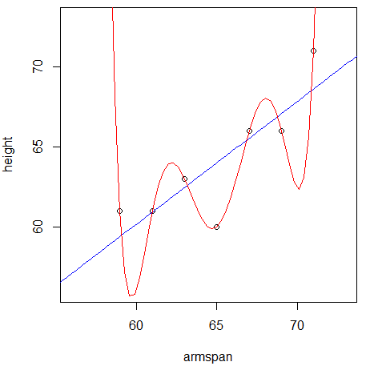

- **Which model does a better job of predicting the 7 `training` points?**
- **Which model do you think will do a better job of predicting the rest of the data?**

# Example of overfitting, continued

- Below is a plot of the rest of the `arm_span` dataset, along with the predictions each model would make.

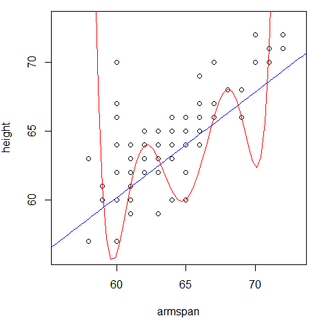

- **Which model does a better job of generalizing to the rest of the `arm_span` dataset?**